# A Machine Algorithm for Human Activity Recognition

Keith Miller

Monday, June 15, 2015

## Executive Summary

This report describes the selection and tuning of a machine-learning algorithm that uses data from personal activity monitors to determine if a particular exercise is being performed in the correct way.

A machine algorithm was created that could predict the exercise being performed with an out-of sample error rate of 1%. When tested against 20 sample prediction problems it successfully predicted all 20.

## Qualitative Activity Recognition

Today, personal activity monitors collect information about how **much** of a particular exercise the wearer is doing but not how **well** they are doing it. This project is an attempt to use data from movement sensors to determine if a user is performing the exercise in the correct way.

The exercise in question is the barbell lift and the data was gathered from acceleromters and gyroscopes placed on the belt, forearm, arm and dumbell of six different participants.

The participants were asked to perform one set of 10 repetitions of the Unilateral Dumbbell Biceps Curl in five different ways: exactly according to the specification (Class A), throwing the elbows to the front (Class B), lifting the dumbbell only halfway (Class C), lowering the dumbbell only halfway (Class D) and throwing the hips to the front (Class E).

Class A corresponds to the specified execution of the exercise, while the other 4 classes correspond to common mistakes. Participants were supervised by an experienced weight lifter to make sure the execution complied to the manner they were supposed to simulate. The exercises were performed by six male participants aged between 20-28 years, with little weight lifting experience. We made sure that all participants could easily simulate the mistakes in a safe and controlled manner by using a relatively light dumbbell (1.25kg).

Read more: http://groupware.les.inf.puc-rio.br/har#ixzz3dAGZdbd3

## Feature Extraction

The selection of the features that could be used in the training data is described in 1.

“For feature extraction we used a sliding window approach with different lengths from 0.5 second to 2.5 seconds, with 0.5 second overlap. In each step of the sliding window approach we calculated features on the Euler angles (roll, pitch and yaw), as well as the raw accelerometer, gyroscope and magnetometer readings. For the Euler angles of each of the four sensors we calculated eight features: mean, variance, standard deviation, max, min, amplitude, kurtosis and skewness, generating in total 96 derived feature sets.”

## Exploratory Data Analysis and Pre-Processing

Two datasets were provided. The training set is 19622 observations of 159 features and 1 categorical response (Levels A-E). The testing set has just 20 observations of the 159 features and an id number for each. After some initial modelling work, it was determined that using 50% of the data for model selection and tuning was adequate and the remainder could be set aside for cross-validation and out-of-sample error rate estimation. All the pre-processing that was applied to the training set was also be applied validation and test sets.

```r
# Split training datasets into train and validation sets
set.seed(601)
trainrecords<-createDataPartition(train$classe,p=0.5,list = F)
trainset<-train[trainrecords,]
validset<-train[-trainrecords,]
```

Reviewing the data, it was determined that many of the features have a large number of NA data and/or a large number of blank values. These columns will be removed from the dataset. Further, the features in columns 1-7 will not be included in a prediction model as they do not characterize the behavior that we are trying to assess - they relate to the time of day, the subject performing the exercise and the group of results that is summarized by the observation.

```r
trainset[1:5,1:7]
```

```
##     X user_name raw_timestamp_part_1 raw_timestamp_part_2   cvtd_timestamp
## 2   2  carlitos           1323084231               808298 05/12/2011 11:23
## 5   5  carlitos           1323084232               196328 05/12/2011 11:23
## 7   7  carlitos           1323084232               368296 05/12/2011 11:23
## 9   9  carlitos           1323084232               484323 05/12/2011 11:23
## 10 10  carlitos           1323084232               484434 05/12/2011 11:23
##    new_window num_window
## 2          no         11
## 5          no         12
## 7          no         12
## 9          no         12
## 10         no         12
```

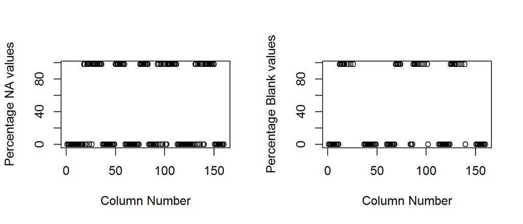

```r
#identifies those variables where more than 50% of the values are NA or blank and removes them

perc.na<-function(x) sum(is.na(x))/length(x)*100
perc.blank<-function(x) sum(x=="")/length(x)*100
NAcols<-apply(trainset,2,perc.na)
Blankcols<-apply(trainset,2,perc.blank)

par(mfrow=(c(1,2)))
plot(NAcols, xlab = "Column Number", ylab = "Percentage NA values")
plot(Blankcols,xlab = "Column Number", ylab = "Percentage Blank values")
```

All columns in the upper groups in these plots will be removed from the dataset

```r
badcols<-c(which(NAcols>0.9),which(Blankcols>0.9))
trainset<- trainset[,-c(1:7,badcols)]
validset<- validset[,-c(1:7,badcols)]   #same changes made to validation set
test    <- test[,-c(1:7,badcols)]  #same changes made to test set
```

Features that have little or no variability and variables that are highly correlated with other variables can cause problems in certain models. These features were also removed from the dataset.

```r
#check for zero-variance predictors
zero.cols<-nearZeroVar(trainset)
if (length(zero.cols)>0) {trainset<-trainset[,-zero.cols];validset<-validset[,-zero.cols];test<-test[,-zero.cols]}

#check for multi-collinearity and remove highly correlated variables
ytrain<-trainset$classe
yvalid<-validset$classe
trainset$classe<-NULL
validset$classe<-NULL
M<-cor(trainset)
cor.cols<-findCorrelation(M,0.9)
if (length(cor.cols)>0){trainset<-trainset[,-cor.cols];validset<-validset[,-cor.cols];test<-test[,-cor.cols]}
```

## Model Selection

The caret package in R creates a consistent way of accessing all the functions and models that R has to offer, offers a set of tools that semi-automates model selection, pre-processing, parameter tuning and resampling strategy and allows parallel testing of models on multi-core machines thus speeding the process of model selection.

The approach used was to first apply the *train* function in caret in its default mode, not giving it any parameters or selecting a model type or cross-validation approach. This yielded very promising results as can be seen below. Prediction accuracy was used as the measure of model effectiveness when choosing the model.

```r
cl <- makeCluster(detectCores())
registerDoParallel(cl)
firsttry<-train(ytrain~.,data=trainset)

firsttry
```

```
## Random Forest
##
## 9812 samples
##   46 predictor
##    5 classes: 'A', 'B', 'C', 'D', 'E'
##
## No pre-processing
## Resampling: Bootstrapped (25 reps)
##
## Summary of sample sizes: 9812, 9812, 9812, 9812, 9812, 9812, ...
##
## Resampling results across tuning parameters:
##
##   mtry  Accuracy   Kappa      Accuracy SD  Kappa SD
##    2    0.9793275  0.9738445  0.002695575  0.003409482
##   24    0.9830839  0.9786035  0.002507211  0.003165117
##   47    0.9771572  0.9711090  0.003630575  0.004589266
##
## Accuracy was used to select the optimal model using  the largest value.
## The final value used for the model was mtry = 24.
```

```r
confusionMatrix(firsttry)
```

```
## Bootstrapped (25 reps) Confusion Matrix
##
## (entries are percentages of table totals)
##
##           Reference
## Prediction    A    B    C    D    E
##          A 28.1  0.4  0.0  0.0  0.0
##          B  0.1 18.7  0.3  0.0  0.0
##          C  0.0  0.2 17.2  0.3  0.1
##          D  0.0  0.0  0.1 15.9  0.1
##          E  0.0  0.0  0.0  0.0 18.2
```

This yields very promising results with an error rate of around 2% using a random forest with bootstrap resampling. After some tuning which included testing other models, re-casting the features using PCA and trying different resampling and cross-validation approaches, the final model was a random forest with 10-fold cross-validation.

```r
rfallfitcv10<-train(ytrain~.,
                     data=trainset,
                     method = 'rf',
                     trControl = trainControl(method='cv',
                                              number = 10 ))
rfallfitcv10
```

```
## Random Forest
##
## 9812 samples
##   46 predictor
##    5 classes: 'A', 'B', 'C', 'D', 'E'
##
## No pre-processing
## Resampling: Cross-Validated (10 fold)
##
## Summary of sample sizes: 8830, 8832, 8830, 8830, 8831, 8831, ...
##
## Resampling results across tuning parameters:
##
##   mtry  Accuracy   Kappa      Accuracy SD  Kappa SD
##    2    0.9859362  0.9822057  0.002871418  0.003633838
##   24    0.9885864  0.9855599  0.003648592  0.004617526
##   47    0.9852221  0.9813038  0.003439861  0.004354524
##
## Accuracy was used to select the optimal model using  the largest value.
## The final value used for the model was mtry = 24.
```

```r
confusionMatrix(rfallfitcv10)
```

```
## Cross-Validated (10 fold) Confusion Matrix
##
## (entries are percentages of table totals)
##
##           Reference
## Prediction    A    B    C    D    E
##          A 28.4  0.3  0.0  0.0  0.0
##          B  0.0 18.9  0.2  0.0  0.0
##          C  0.0  0.1 17.1  0.2  0.0
##          D  0.0  0.0  0.1 16.2  0.1
##          E  0.0  0.0  0.0  0.0 18.3
```

This yielded a 1% in-sample error rate for the final model

## Out-of-Sample Error Rate Estimation Using Cross-Validation

Having used cross-validation in the selection of features and model, we must use a separate set of data to estimate the out-of-sample error rate. Now we will now cross-validate using our validation data, the other half of the original training set that we started with. Given the similarity of the training and test data, we would expect the out-of-sample rate to be close to the in-sample rate, but probably not as good.

```r
ypreds<-predict(rfallfitcv10, newdata = validset)
confusionMatrix(ypreds,yvalid)
```

```
## Confusion Matrix and Statistics
##
##           Reference
## Prediction    A    B    C    D    E
##          A 2787   16    0    0    0
##          B    0 1875    9    0    0
##          C    0    6 1695   21    4
##          D    0    0    5 1585    4
##          E    3    1    2    2 1795
##
## Overall Statistics
##
##                Accuracy : 0.9926
##                  95% CI : (0.9907, 0.9942)
##     No Information Rate : 0.2844
##     P-Value [Acc > NIR] : < 2.2e-16
##
##                   Kappa : 0.9906
##  Mcnemar's Test P-Value : NA
##
## Statistics by Class:
##
##                      Class: A Class: B Class: C Class: D Class: E
## Sensitivity            0.9989   0.9879   0.9906   0.9857   0.9956
## Specificity            0.9977   0.9989   0.9962   0.9989   0.9990
## Pos Pred Value         0.9943   0.9952   0.9820   0.9944   0.9956
## Neg Pred Value         0.9996   0.9971   0.9980   0.9972   0.9990
## Prevalence             0.2844   0.1935   0.1744   0.1639   0.1838
## Detection Rate         0.2841   0.1911   0.1728   0.1616   0.1830
## Detection Prevalence   0.2857   0.1920   0.1759   0.1625   0.1838
## Balanced Accuracy      0.9983   0.9934   0.9934   0.9923   0.9973
```

## Conclusion

The out-of-sample error rate of <1% is just as good as the in-sample error rate and so the chosen model seems to be effective. When run against the 20 test observations it correctly identified all 20 classes.

## References

1. Velloso, E.; Bulling, A.; Gellersen, H.; Ugulino, W.; Fuks, H. Qualitative Activity Recognition of Weight Lifting Exercises. Proceedings of 4th International Conference in Cooperation with SIGCHI (Augmented Human ’13) . Stuttgart, Germany: ACM SIGCHI, 2013.

Read more: http://groupware.les.inf.puc-rio.br/har#ixzz3dB0epBGD

## Appendix

### The 10 most significant variables in the chosen model

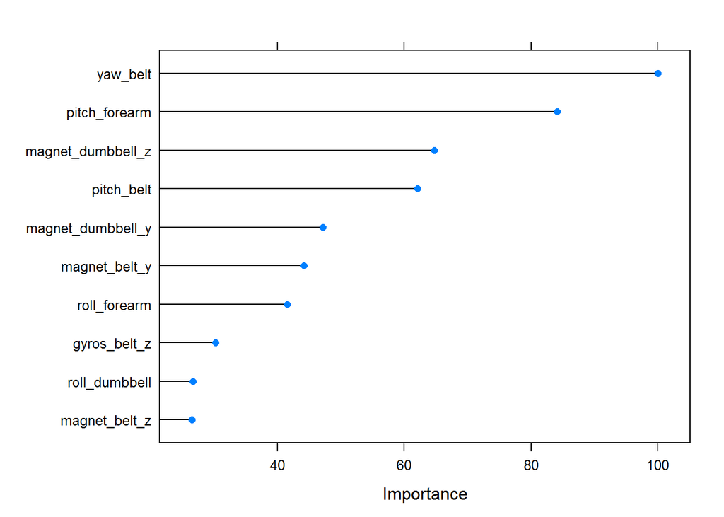

```r
#plots the importance of the top 10 variables in the model
plot(varImp(rfallfitcv10),top =10)
```